# Regularisation

Andres Ponce

# 1 College data set

In this exercise, I will predict the number of applications received using the other variables in the `College` data set.

- Split the data set into a training set and a test set.

```r
require(caTools)
set.seed(123)   #  set seed to ensure you always have same random numbers generated
sample = sample.split(College,SplitRatio = 0.50) # splits the data in the ratio mentioned in SplitRatio. After splitting marks these rows as logical TRUE and the the remaining are marked as logical FALSE
train1 =subset(College,sample ==TRUE) # creates a training dataset named train1 with rows which are marked as TRUE
test1=subset(College, sample==FALSE)
```

## 1.1 GLM

- Fitting a linear model using least squares on the training set.

```
Call:
NULL

Deviance Residuals:
    Min       1Q   Median       3Q      Max
-3222.0   -476.6    -76.9    322.8   6658.5

Coefficients:
            Estimate Std. Error t value Pr(>|t|)
(Intercept)  3096.95      55.22  56.084  < 2e-16 ***
PrivateYes   -410.16      93.48  -4.388 1.49e-05 ***
Accept       3085.46     184.07  16.762  < 2e-16 ***
Enroll       -249.36     305.86  -0.815  0.41543
Top10perc     881.21     147.18   5.987 5.04e-09 ***
Top25perc    -241.11     129.29  -1.865  0.06299 .
F.Undergrad   302.41     306.28   0.987  0.32410
P.Undergrad   -94.73      84.67  -1.119  0.26396
Outstate     -158.78     113.83  -1.395  0.16389
Room.Board    249.92      77.10   3.242  0.00130 **
Books          37.59      58.81   0.639  0.52311
Personal       16.12      62.91   0.256  0.79785
PhD          -143.33     111.39  -1.287  0.19900
Terminal     -105.73     111.52  -0.948  0.34371
S.F.Ratio      91.09      76.12   1.197  0.23226
perc.alumni  -126.07      79.61  -1.584  0.11415
Expend        467.11      91.37   5.113 5.10e-07 ***
Grad.Rate     189.50      72.45   2.615  0.00927 **
---
Signif. codes:  0 *** 0.001 ** 0.01 * 0.05 . 0.1   1

(Dispersion parameter for gaussian family taken to be 1186149)

    Null deviance: 5208835604  on 388  degrees of freedom
Residual deviance:  440061231  on 371  degrees of freedom
AIC: 6564.1

Number of Fisher Scoring iterations: 2
```

```
       RMSE    Rsquared         MAE
1114.881777    0.929867  632.593001
```

## 1.2 Ridge Regression

- ridge regression model on the training set, with $\lambda$ chosen by cross-validation.

```r
require(elasticnet)
xtrain <- model.matrix(Apps~., train1)[,-1]
ytrain <- train1$Apps
xtest <- model.matrix(Apps~., test1)[,-1]
ytest <- test1$Apps
grid <- 10^ seq (10, -2 , length =100)
tuneGrid <- expand.grid(lambda= grid, alpha =0)
ctrl <- trainControl(method = "cv", number=5)
ridge <- train(xtrain, ytrain,
                  method = "glmnet",
                  trControl = ctrl,
               tuneGrid= tuneGrid,
                  preProc = c("center", "scale"))
```

```
There were missing values in resampled performance measures.
```

```
[1] 305.3856
18 x 1 sparse Matrix of class "dgCMatrix"
                     1
(Intercept) 3096.95116
PrivateYes  -355.66331
Accept      1827.57725
Enroll       637.94523
Top10perc    465.61972
Top25perc     36.36633
F.Undergrad  576.20591
P.Undergrad  -77.02288
Outstate      28.40582
Room.Board   267.22388
Books         71.06459
Personal     -24.38505
PhD          -58.57179
Terminal    -121.03836
S.F.Ratio     51.62515
perc.alumni -214.95627
Expend       445.99361
Grad.Rate    231.64318
        RMSE     Rsquared          MAE
1449.4390011    0.8874841  704.9194474
```

```
        RMSE     Rsquared          MAE
1449.4390011    0.8874841  704.9194474
```

## 1.3 Lasso Regression

- lasso model on the training set, with $\lambda$ chosen by cross-validation.

```
There were missing values in resampled performance measures.
```

```
[1] 10.72267
18 x 1 sparse Matrix of class "dgCMatrix"
                      1
(Intercept) 3096.951157
PrivateYes  -401.570444
Accept      2998.940315
Enroll         .
Top10perc    759.349934
Top25perc   -133.660366
F.Undergrad  105.363764
P.Undergrad  -46.988361
Outstate    -114.562426
Room.Board   227.852960
Books         34.293165
Personal       8.850658
PhD         -115.785778
Terminal    -105.592734
S.F.Ratio     68.929908
perc.alumni -125.828529
Expend       445.183600
Grad.Rate    169.879700
```

```
        RMSE     Rsquared          MAE
1121.3082670    0.9301081  620.6651242
```

## 1.4 Principal Component Regression

- PCR model on the training set, with $M$ chosen by cross-validation.

[output not shown]

[output not shown]

```
Principal Component Analysis

389 samples
 17 predictor

Pre-processing: centered (17), scaled (17), principal component signal extraction (17)
Resampling: Cross-Validated (5 fold)
Summary of sample sizes: 311, 311, 311, 311, 312
Resampling results across tuning parameters:

  ncomp  RMSE      Rsquared     MAE
  1      3644.681  0.006387387  2596.594
  2      1825.170  0.743747655  1321.255
  3      1832.567  0.740937534  1332.871

RMSE was used to select the optimal model using the smallest value.
The final value used for the model was ncomp = 2.
```

```
        RMSE     Rsquared          MAE
2232.3852032    0.6989101 1272.6173633
```

```r
sum(College$Apps)
```

```
[1] 2332273
```

# 2 Capital Bikeshare system, Washington D.C. dataset

- I use the datafrom Capital Bikeshare system, Washington D.C. I expect that the use of bike rentals is highly correlated to the environmental and seasonal settings and daily weather conditions. the aim is to predict the use of the service (var count of total rental bikes) given the presumably highly collinear variables in the dataset. I want to test how the models perform in the presence of such high correlation among predictors.

========================================= Dataset characteristics =========================================  
Both hour.csv and day.csv have the following fields, except hr which is not available in day.csv

```
- dteday : date
- season : season (1:springer, 2:summer, 3:fall, 4:winter)
- yr : year (0: 2011, 1:2012)
- mnth : month ( 1 to 12)
- hr : hour (0 to 23)
- holiday : weather day is holiday or not (extracted from http://dchr.dc.gov/page/holiday-schedule)
- weekday : day of the week
- workingday : if day is neither weekend nor holiday is 1, otherwise is 0.
+ weathersit :
    - 1: Clear, Few clouds, Partly cloudy, Partly cloudy
    - 2: Mist + Cloudy, Mist + Broken clouds, Mist + Few clouds, Mist
    - 3: Light Snow, Light Rain + Thunderstorm + Scattered clouds, Light Rain + Scattered clouds
    - 4: Heavy Rain + Ice Pallets + Thunderstorm + Mist, Snow + Fog
- temp : Normalized temperature in Celsius. The values are divided to 41 (max)
- atemp: Normalized feeling temperature in Celsius. The values are divided to 50 (max)
- hum: Normalized humidity. The values are divided to 100 (max)
- windspeed: Normalized wind speed. The values are divided to 67 (max)
- casual: count of casual users
- registered: count of registered users
- cnt: count of total rental bikes including both casual and registered
```

```
[1] "D:/Machine Learning/5"
'data.frame':   17379 obs. of  17 variables:
 $ instant   : int  1 2 3 4 5 6 7 8 9 10 ...
 $ dteday    : Factor w/ 731 levels "2011-01-01","2011-01-02",..: 1 1 1 1 1 1 1 1 1 1 ...
 $ season    : int  1 1 1 1 1 1 1 1 1 1 ...
 $ yr        : int  0 0 0 0 0 0 0 0 0 0 ...
 $ mnth      : int  1 1 1 1 1 1 1 1 1 1 ...
 $ hr        : int  0 1 2 3 4 5 6 7 8 9 ...
 $ holiday   : int  0 0 0 0 0 0 0 0 0 0 ...
 $ weekday   : int  6 6 6 6 6 6 6 6 6 6 ...
 $ workingday: int  0 0 0 0 0 0 0 0 0 0 ...
 $ weathersit: int  1 1 1 1 1 2 1 1 1 1 ...
 $ temp      : num  0.24 0.22 0.22 0.24 0.24 0.24 0.22 0.2 0.24 0.32 ...
 $ atemp     : num  0.288 0.273 0.273 0.288 0.288 ...
 $ hum       : num  0.81 0.8 0.8 0.75 0.75 0.75 0.8 0.86 0.75 0.76 ...
 $ windspeed : num  0 0 0 0 0 0.0896 0 0 0 0 ...
 $ casual    : int  3 8 5 3 0 0 2 1 1 8 ...
 $ registered: int  13 32 27 10 1 1 0 2 7 6 ...
 $ cnt       : int  16 40 32 13 1 1 2 3 8 14 ...
```

|  | instant | dteday | season | yr | mnth | hr | holiday | weekday | workingday | weathersit | temp | atemp | hum | windspeed | casual | registered | cnt |
| --- | --- | --- | --- | --- | --- | --- | --- | --- | --- | --- | --- | --- | --- | --- | --- | --- | --- |
| 1 | 1 | 2011-01-01 | 1 | 0 | 1 | 0 | 0 | 6 | 0 | 1 | 0.24 | 0.2879 | 0.81 | 0.0000 | 3 | 13 | 16 |
| 2 | 2 | 2011-01-01 | 1 | 0 | 1 | 1 | 0 | 6 | 0 | 1 | 0.22 | 0.2727 | 0.80 | 0.0000 | 8 | 32 | 40 |
| 3 | 3 | 2011-01-01 | 1 | 0 | 1 | 2 | 0 | 6 | 0 | 1 | 0.22 | 0.2727 | 0.80 | 0.0000 | 5 | 27 | 32 |
| 4 | 4 | 2011-01-01 | 1 | 0 | 1 | 3 | 0 | 6 | 0 | 1 | 0.24 | 0.2879 | 0.75 | 0.0000 | 3 | 10 | 13 |
| 5 | 5 | 2011-01-01 | 1 | 0 | 1 | 4 | 0 | 6 | 0 | 1 | 0.24 | 0.2879 | 0.75 | 0.0000 | 0 | 1 | 1 |
| 6 | 6 | 2011-01-01 | 1 | 0 | 1 | 5 | 0 | 6 | 0 | 2 | 0.24 | 0.2576 | 0.75 | 0.0896 | 0 | 1 | 1 |
| 7 | 7 | 2011-01-01 | 1 | 0 | 1 | 6 | 0 | 6 | 0 | 1 | 0.22 | 0.2727 | 0.80 | 0.0000 | 2 | 0 | 2 |
| 8 | 8 | 2011-01-01 | 1 | 0 | 1 | 7 | 0 | 6 | 0 | 1 | 0.20 | 0.2576 | 0.86 | 0.0000 | 1 | 2 | 3 |
| 9 | 9 | 2011-01-01 | 1 | 0 | 1 | 8 | 0 | 6 | 0 | 1 | 0.24 | 0.2879 | 0.75 | 0.0000 | 1 | 7 | 8 |
| 10 | 10 | 2011-01-01 | 1 | 0 | 1 | 9 | 0 | 6 | 0 | 1 | 0.32 | 0.3485 | 0.76 | 0.0000 | 8 | 6 | 14 |

```
data in column(s) 'dteday' are not numeric and were ignored
```

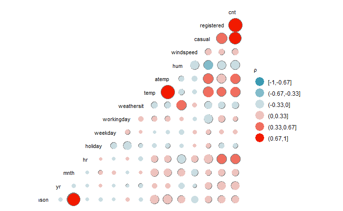

## 2.1 GLM

```r
require(caTools)
set.seed(123)   #  set seed to ensure you always have same random numbers generated
sample = sample.split(Bike,SplitRatio = 0.50) # splits the data in the ratio mentioned in SplitRatio. After splitting marks these rows as logical TRUE and the the remaining are marked as logical FALSE
train1_bike =subset(Bike,sample ==TRUE) # creates a training dataset named train1 with rows which are marked as TRUE
test1_bike=subset(Bike, sample==FALSE)
#Subsets for EU models
xtrain_bike <- model.matrix(cnt~., train1_bike)[,-1]
ytrain_bike <- train1_bike$cnt
xtest_bike <- model.matrix(cnt~., test1_bike)[,-1]
ytest_bike <- test1_bike$cnt
#preproc
grid_bike <- 10^ seq (10, -2 , length =100)
tuneGrid_bike <- expand.grid(lambda= grid_bike, alpha =0)
ctrl_bike <- trainControl(method = "cv", number=5)
```

```r
lm_bike<- train(cnt ~ .
                        ,train1_bike
                        ,method = "glm",
                    preProc = c("center", "scale")
                        )
summary(lm_college)
```

[output not shown]

```r
bike_pred <- predict(lm_bike, test1_bike)
```

```
      RMSE   Rsquared        MAE
61.2871931  0.9490069 36.0767637
```

## 2.2 Ridge Regression

```
There were missing values in resampled performance measures.
```

```
[1] 14.17474
16 x 1 sparse Matrix of class "dgCMatrix"
                       1
(Intercept) 184.83118527
dteday        1.68731989
season        1.71608426
yr            2.36414038
mnth         -0.05262474
hr            4.73066117
holiday      -0.27491996
weekday       0.24758611
workingday    1.69821112
weathersit   -0.45607046
temp          1.56917540
atemp         2.07598818
hum          -2.83180469
windspeed     0.49364331
casual       48.69007512
registered  126.38008364
      RMSE   Rsquared        MAE
15.7716124  0.9975254 11.0649818
```

```
glmnet variable importance
```

|  | Overall |
| --- | --- |
| registered | 100.0000000 |
| casual | 38.5010914 |
| hr | 3.7031034 |
| hum | 2.1999809 |
| yr | 1.8297808 |
| atemp | 1.6016814 |
| season | 1.3167838 |
| workingday | 1.3026355 |
| dteday | 1.2940141 |
| temp | 1.2004917 |

[output cut: 5 more lines]

## 2.3 Lasso Regression

```
There were missing values in resampled performance measures.
```

```
[1] 3.511192
16 x 1 sparse Matrix of class "dgCMatrix"
                    1
(Intercept) 184.83119
dteday        .
season        .
yr            .
mnth          .
hr            .
holiday       .
weekday       .
workingday    .
weathersit    .
temp          .
atemp         .
hum           .
windspeed     .
casual       46.07944
registered  140.83553
     RMSE  Rsquared       MAE
5.4725704 0.9999388 4.2382555
```

```
glmnet variable importance
```

|  | Overall |
| --- | --- |
| registered | 100.00000 |
| casual | 32.71862 |
| atemp | 0.00000 |
| workingday | 0.00000 |
| windspeed | 0.00000 |
| dteday | 0.00000 |
| season | 0.00000 |
| temp | 0.00000 |
| hum | 0.00000 |
| weathersit | 0.00000 |

[output cut: 5 more lines]

- The lasso model perform better than the linear model and the Ridge model, this conclusion is based on the RMSE of 5.4725704 as compared to 15.7716124 and 61.2871931 respectively. All the models where trainned on random subsample of 8690 observations (50%) of the general data. Furthermore, the ridge and lasso model considered a 5 k-fold cross validation process. In sum, all models were finally compared to the held out test data sample in order to assest the best model perfomance. In this regard, the lasso model perform substantially better than the other ones.
- The lasso model does not involve all the features present in the dataset. In fact the penalizing factor drop most of the variables, except for the ones that are higly related to the dependent variable. In this case I would argue that the remaining variable in the model are highly correlated with each other, producing also endogeneity among the regressors. In this sense, did the lasso mistakenly drop all the variables, realizing the strong endogeneity bias between the remaining variables (?), that indeed might be a possibility.